# Modelos de Volatilidad

v. 2026.04.27

## Introducción

## Hechos estilizados (1/3)

Antes, hemos supuesto que la varianza de los errores, \(\sigma^2\), era constante. Sin embargo, las series de tiempo económicas y financieras a menudo violan este supuesto.

Existen dos hechos estilizados clave que motivan la necesidad de modelos de volatilidad.

## Hechos estilizados (2/3)

Agrupamiento de Volatilidad (**Volatility Clustering**)

Muchas series financieras exhiben períodos de calma seguidos de períodos de alta turbulencia. Los periodos de alta (baja) turbulencia tienden a agruparse.

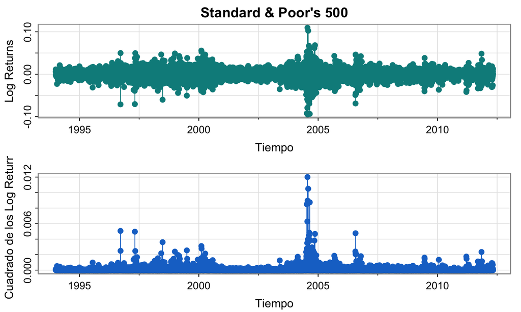

## Hechos estilizados (3/3)

Colas Pesadas (**Leptokurtosis**)

Las distribuciones de los rendimientos financieros suelen tener colas más pesadas que una distribución normal: los eventos extremos (grandes caídas o subidas) ocurren con más frecuencia de lo que se esperaría bajo normalidad.

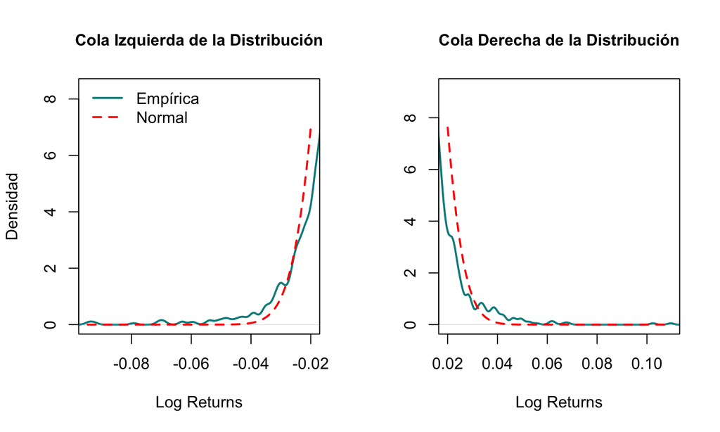

## Heteroscedasticidad condicional

Estos hechos estilizados sugieren que la varianza, *aunque puede ser constante en el largo plazo (no condicional), varía en el corto plazo dependiendo de la información disponible*. Esto es la **heteroscedasticidad condicional**

## Modelos ARCH

## Modelos ARCH (1/4)

Sea \(y_t\) una serie de tiempo. Esta puede seguir, por ejemplo, un proceso ARMA(\(p,q\)) que puede incluir algunas variables explicativas adicionales (que por sí mismas podrían ser series de tiempo):

\[ \begin{align} y_t &= \phi_0 + \boldsymbol{\beta}\mathbf{x}_t + \sum_{i=1}^p \phi_i y_{t-i} + \sum_{j=1}^q \theta_j \varepsilon_{t-j} + \varepsilon_t\\ \varepsilon_t & \sim WN(0,\sigma^2) \end{align} \]

## Modelos ARCH (2/4)

A diferencia de lo que hemos hecho antes, supondremos ahora que:

\[ \begin{align} \varepsilon_t^2 &= \alpha_0 + \alpha_1 \varepsilon_{t-1}^2 + \alpha_2 \varepsilon_{t-2}^2 + \dots + \alpha_m \varepsilon_{t-m}^2 + \omega_t \\ \alpha_0&>0; \ \alpha_i \geq 0; \ i=1,\dots,m \\ \omega_t &\sim WN (0,\lambda^2) \end{align} \]

## Modelos ARCH (3/4)

El supuesto anterior implica que:

\[ \mathbb{E}(\varepsilon_t^2|\varepsilon_{t-1},\varepsilon_{t-2},\dots,\varepsilon_{t-m}) = \alpha_0 + \alpha_1 \varepsilon_{t-1}^2 + \alpha_2 \varepsilon_{t-2}^2 + \dots + + \alpha_m \varepsilon_{t-m}^2 \]

Es decir, aunque la varianza no condicional de \(\varepsilon_t\) sigue siendo constante (igual a \(\sigma^2\)), *la varianza condicional no lo es*. Cuando esto ocurre tenemos que:

\[ \varepsilon_{t} \sim \text{ARCH}(m) \]

## Modelos ARCH (4/4)

Nota

Para que el proceso que sigue \(\varepsilon_t\) *sea estacionario*, es necesario que las raíces del polinomio:

\[ 1- \alpha_1 L - \alpha_2 L^2 - \dots - \alpha_m L^m =0 \] se encuentren *fuera del círculo unitario*. Si todos los \(\alpha_i\) son no-negativos, esto es equivalente a:

\[ \alpha_1 + \alpha_2 + \dots + \alpha_m <1 \]

Además, en este caso, es fácil demostrar que:

\[ \begin{align} \sigma^2 &=\mathbb{E}(\varepsilon_t^2) \\ &=\frac{\alpha_0}{1-\sum_{i=1}^m \alpha_i} \end{align} \]

## Interpretación de los parámetros en ARCH(\(m\))

Los coeficientes \(\alpha_i\) actúan como *pesos* que determinan cuánto influyen los choques pasados en la volatilidad actual.

- Si los \(\alpha_i\) son grandes, la respuesta de la varianza condicional a los choques es *persistente*.
- Si los \(\alpha_i\) son pequeños, los efectos de los choques pasados se disipan rápidamente.

> En un ARCH(\(1\)), la persistencia se mide directamente con el valor de \(\alpha_1\).

## Fórmula alternativa de un ARCH(\(m\)) (1/2)

Una forma alternativa de escribir un ARCH(\(m\)) consiste en suponer que:

\[ \begin{align} \varepsilon_t &= \upsilon_t \sqrt{h_t}\\ \upsilon_t &\sim iid (0,1) \end{align} \] Donde:

\[ h_t = \alpha_0 + \alpha_1 \varepsilon_{t-1}^2 + \alpha_2 \varepsilon_{t-2}^2 + \dots + \alpha_m \varepsilon_{t-m}^2 \] Es fácil demostrar que, en este caso:

\[ \mathbb{E}(\varepsilon_t^2|\varepsilon_{t-1},\varepsilon_{t-2},\dots,\varepsilon_{t-m}) = h_t \]

## Fórmula alternativa de un ARCH(\(m\)) (2/2)

Si combinamos ambas formas de escribir un modelo ARCH(\(m\)) podemos encontrar las *condiciones para que \(\lambda_t\) exista*. Por ejemplo, para un ARCH(\(1\)):

\[ h_t = \alpha_0 + \alpha_1 \varepsilon_{t-1}^2 \]

- Una condición necesaria para que \(\lambda_t\) exista es que :

\[ 0 \le \alpha_1 < 1 \]

- Además, si hacemos el supuesto adicional que \(\upsilon_t\sim\mathcal{N}(0,1)\), podemos obtener que, para que exista un cuarto momento finito (y, por tanto, kurtosis finita):

\[ \alpha_1^2 < \frac{1}{3} \]

## Propiedades de los modelos ARCH: Volatility clustering

Consideremos un ARCH(1):

\[ h_t = \alpha_0 + \alpha_1 \varepsilon_{t-1}^2 \] Nota que:

- Si \(\alpha_1\) es grande (cercano a 1), un choque grande en \(\varepsilon_{t-1}\) aumenta \(h_t\) de manera persistente.
- Esto produce el **agrupamiento de volatilidad** observado en los datos financieros.
- Los períodos de alta (baja) varianza tienden a ser seguidos por otros de alta (baja) varianza.

## Propiedades de los modelos ARCH: leptokurtosis (1/2)

Nota que, aun si \(\upsilon_t \sim N(0,1)\), los errores \(\varepsilon_t\) de un modelo ARCH presentan *colas más pesadas* que la normal:

\[ \text{Kurt}(\varepsilon_t) = 3\frac{1-\alpha_1^2}{1-3\alpha_1^2} \; > 3 \quad \text{si } \alpha_1^2 < \tfrac{1}{3}. \] Entonces:

- Los valores grandes de \(|\varepsilon_t|\) ocurren con mayor frecuencia de la esperada bajo normalidad.
- Esto se debe a que \(h_t\) cambia en el tiempo: los periodos con varianza alta generan choques más grandes.

**Nota.** La leptocurtosis en los modelos ARCH surge *endógenamente* debido a la variabilidad de \(h_t\). No es necesario suponer una distribución no normal de los errores para obtener colas pesadas.

## Propiedades de los modelos ARCH: leptokurtosis (2/2)

Ejercicio

Muestra que, para un ARCH(\(1\)) con \(\upsilon_t \sim N(0,1)\):

\[ \text{Kurt}(\varepsilon_t) = 3\frac{1-\alpha_1^2}{1-3\alpha_1^2} \; > 3 . \]

## Efectos ARCH

Antes de aplicar pruebas formales, puede observarse la heteroscedasticidad condicional de manera gráfica. Para esto:

1. Estimamos el modelo y recuperamos sus residuales: \(e_t\).
2. Examinamos su correlograma de \(e_t^2\). Si se observan patrones de agrupamiento o autocorrelaciones significativas, tenemos evidencia de efectos ARCH.

## Prueba para los efectos ARCH

Prueba ARCH-LM de Engle (1982). Supongamos que tenemos un modelo ARMA con variables explicativas.

1. Estimamos el modelo y recuperamos sus residuales: \(e_t\).
2. Estimamos el siguiente modelo: \[ e_t^2 = \alpha_0 + \alpha_1 e_{t-1}^2 + \alpha_2 e_{t-2}^2 + \dots + \alpha_m e_{t-m}^2 + u_t \]
3. Utilizamos el estadístico \(TR^2\) para probar la siguiente hipótesis:

   \[ \begin{align} H_0:& \ \alpha_1 = \alpha_2 = \dots = \alpha_m = 0 \\ H_1: &\ \text{Al menos un }\alpha_i\neq 0\\ TR^2 & \sim \chi^2_m \end{align} \]

> **Nota**. Dado que un modelo ARCH(\(m\)) puede interpretarse como un modelo AR(\(m\)) aplicado a los residuales al cuadrado, el correlograma de \(e_t^2\) también ayuda a identificar el valor de \(m\).

## Estimación de un modelo con efectos ARCH (1/2)

Los modelos con efectos ARCH se estiman por el *método de máxima verosimilitud*.

Cuando \(\upsilon_t\sim iid \mathcal{N}(0,1)\), no es difícil demostrar que:

\[ f(y_t|\mathbf{x,\Omega}) = \frac{1}{\sqrt{2\pi h_t}}\exp\left\{-\frac{1}{2h_t}\left(y_t-\boldsymbol{\beta}\mathbf{x}_t\right)^2\right\} \] donde:

\[ \begin{align} h_t &= \alpha_0 + \alpha_1 \varepsilon_{t-1}^2 + \alpha_2 \varepsilon_{t-2}^2 + \dots + \alpha_m \varepsilon_{t-m}^2 \\ &= \alpha_0 + \alpha_1(y_{t-1}- \boldsymbol{\beta}\mathbf{x}_{t-1})^2 + \alpha_2(y_{t-2}- \boldsymbol{\beta}\mathbf{x}_{t-2})^2+\dots+ \alpha_m(y_{t-m}- \boldsymbol{\beta}\mathbf{x}_{t-m})^2 \end{align} \]

## Estimación de un modelo con efectos ARCH (2/2)

Entonces, la función de verosimilitud de un ARCH(\(m\)) bajo el supuesto de normalidad es:

\[ \mathcal{L}(\boldsymbol{\theta}) = - \frac{T}{2}\ln(2\pi) - \frac{1}{2}\sum_{t=1}^T\ln(h_t) - \frac{1}{2}\sum_{t=1}^T\frac{\left(y_{t}- \boldsymbol{\beta}\mathbf{x}_{t}\right)^2}{h_t} \]

## Pronósticos en modelos ARCH (1/4)

Considera un modelo ARCH(\(1\)):

\[ \begin{align} h_t &= \alpha_0 + \alpha_1 \varepsilon_{t-1}^2\\ \varepsilon_t &= \upsilon_t \sqrt{h_t}\\ \upsilon_t &\sim iid(0,1) \end{align} \] Deseamos calcular:

\[ \widehat{h}_{T+s\mid T} = \mathbb{E}(h_{T+s}\mid \Omega_T) \] *Este pronóstico puede obtenerse mediante iteración*.

## Pronósticos en modelos ARCH (2/4)

No es difícil encontrar que:

\[ \widehat{h}_{T+s\mid T} = \begin{cases} \alpha_0 + \alpha_1\varepsilon_T^2; & \ s=1\\ \alpha_0 + \alpha_1h_{T+s-1}; & \ s>1 \end{cases} \] Esto implica que:

\[ \widehat{h}_{T+s\mid T} = \alpha_0 \sum_{j=0}^{s-1} \alpha_1^j + \alpha_1^s \varepsilon_T^2. \]

## Pronósticos en modelos ARCH (3/4)

Nota que:

\[ \begin{align} \lim_{s\to\infty}\widehat{h}_{T+s\mid T} &= \frac{\alpha_0}{1-\alpha_1}\\ &= \sigma^2 \end{align} \] Esto es:

- Conforme crece \(h\), el pronóstico converge a la varianza no condicional.
- Cuanto mayor sea \(\alpha_1\), más lentamente se alcanza la convergencia.
- Si \(\alpha_1\) es cercano a \(1\), los choques afectan la volatilidad por más tiempo.

## Pronósticos en modelos ARCH (4/4)

Ejercicio

Muestra que, para un modelo ARCH(\(1\)):

\[ \begin{align} h_t &= \alpha_0 + \alpha_1 \varepsilon_{t-1}^2\\ \varepsilon_t &= \upsilon_t \sqrt{h_t}\\ \upsilon_t &\sim iid(0,1), \end{align} \] tenemos que:

\[ \widehat{h}_{T+s\mid T} = \alpha_0 \sum_{j=0}^{s-1} \alpha_1^j + \alpha_1^s h_T. \]

*Pista*. Usa la ley de las expectativas iteradas y que \(\mathbb{E}(\varepsilon_t^2\mid\Omega_{t-1})=h_t\).

## Ejemplo ARCH: NYSE (1/3)

Considera la tasa de rendimiento diario de la NYSE U.S. 100 del 4 de enero del 2000 al 16 de julio del 2012:

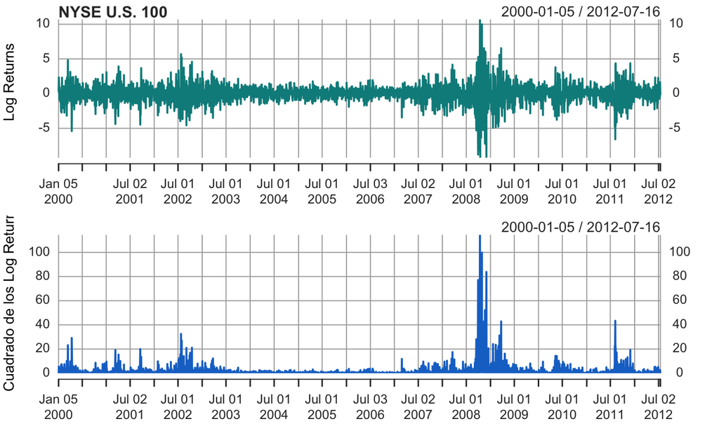

## Ejemplo ARCH: NYSE (2/3)

Ajustamos el siguiente modelo:

\[ \begin{align} y_t &= \phi_0 + \varepsilon_t\\ \varepsilon_t &= \upsilon_t\sqrt{h_t} \\ h_t & = \alpha_0 + \alpha_1\varepsilon_{t-1}^2 \end{align} \]

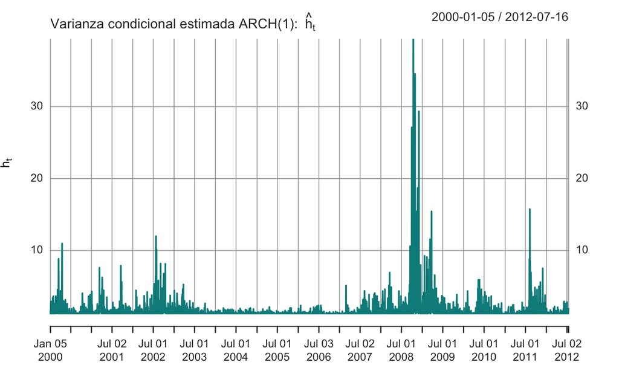

## Ejemplo ARCH: NYSE (3/3)

Finalmente, un pronóstico de \(h_t\) para \(s=20\) periodos hacia adelante resulta en:

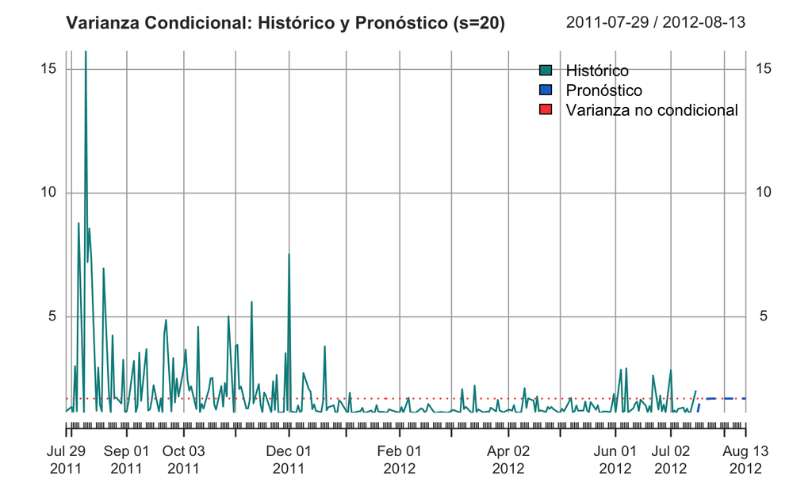

## Modelos GARCH

## Modelos GARCH (1/5)

Imaginemos ahora que:

\[ \begin{align} \varepsilon_t &= \upsilon_t \sqrt{h_t}\\ \upsilon_t &\sim iid (0,1) \end{align} \]

Pero ahora:

\[ \begin{align} h_t &= \alpha_0 + \Pi(L)\varepsilon_t^2\\ \Pi(L)&=\sum_{j=1}^\infty \pi_j L^j \end{align} \]

## Modelos GARCH (2/5)

Para parametrizar el polinomio \(\Pi(L)\), podemos suponer que:

\[ \begin{align} \Pi(L) &= \frac{\alpha(L)}{1-\delta(L)} \\ &=\frac{\alpha_1 L + \alpha_2 L^2 +\dots+ \alpha_m L^m}{1-\delta_1 L - \delta_2 L^2 -\dots- \delta_r L^r} \end{align} \] donde, por ahora, supondremos que las raíces del polinomio \(1-\delta(L)=0\) se encuentran fuera del círculo unitario.

Se puede demostrar que esto implica que:

\[ \begin{align} h_t = \kappa &+ \delta_1 h_{t-1} + \delta_2 h_{t-2} + \dots + \delta_r h_{t-r} \\ & + \alpha_1 \varepsilon_{t-1}^2 + \alpha_2 \varepsilon_{t-2}^2 + \dots + \alpha_m \varepsilon_{t-m}^2 \end{align} \] con \(\kappa = (1-\delta_1-\delta_2-\dots-\delta_r)\alpha_0\).

## Modelos GARCH (3/5)

El resultado es un modelo **ARCH generalizado** (Bollerslev, 1986), GARCH(\(r,m\)):

\[ \varepsilon_t \sim \text{GARCH}(r,m) \]

## Modelos GARCH (4/5)

Nota que:

\[ \begin{align} h_t + \varepsilon_t^2 = \kappa & - \delta_1 (\varepsilon_{t-1}^2 - h_{t-1}) - \delta_2 (\varepsilon_{t-2}^2 - h_{t-2}) - \dots - \delta_r(\varepsilon_{t-r}^2 - h_{t-r}) \\ &+ \delta_1 \varepsilon_{t-1}^2 + \delta_2 \varepsilon_{t-2}^2 + \dots + \delta_r \varepsilon_{t-r}^2 \\ & + \alpha_1 \varepsilon_{t-1}^2 + \alpha_2 \varepsilon_{t-2}^2 + \dots + \alpha_m \varepsilon_{t-m}^2 + \varepsilon_t^2 \end{align} \] O:

\[ \begin{align} \varepsilon_t^2 = \kappa & + \sum_{i=1}^p(\delta_i +\alpha_i) \varepsilon_{t-i}^2 + \omega_{t} \\ & - \sum_{j=1}^r\delta_j \omega_{t- j}, \end{align} \] donde \(\omega_t = \varepsilon_t^2-h_t\) es un **ruido blanco condicionalmente heteroscedástico** y \(p=\max(m,r)\). Esto es, *si \(\varepsilon_t \sim GARCH(r,m)\), entonces \(\varepsilon_t^2 \sim ARMA(p,r)\)*.

## Modelos GARCH (5/5)

Si suponemos que \(\kappa>0\), \(\alpha_i \geq 0\) y \(\delta_j \geq 0\), entonces, de nuestro análisis de los modelos ARMA, podemos deducir que un modelo GARCH(\(r,m\)) es estacionario si todas las raíces del polinomio:

\[ 1-(\delta_1+\alpha_1)L-(\delta_2+\alpha_2)L^2-\dots-(\delta_p+\alpha_p)L^p =0 \] *se encuentran fuera del círculo unitario*. Dado la no-negatividad de los coeficientes, la condición de estacionariedad se simplifica a:

\[ (\delta_1+\alpha_1)+(\delta_2+\alpha_2)+\dots+(\delta_p+\alpha_p)<1. \]

Además, en este caso, se puede demostrar que:

\[ \sigma^2=\frac{\kappa}{1-\sum_{i=1}^p(\delta_i+\alpha_i)} \]

## Propiedades de los modelos GARCH: Volatility clustering

Consideremos un GARCH(\(1,1\)):

\[ h_t = \kappa + \alpha_1\varepsilon_{t-1}^2 + \delta_1h_{t-1}, \qquad \kappa>0,\ \alpha_1, \ \delta_1\ge0. \]

Observa que:

- Un choque grande en \(\varepsilon_{t-1}\) incrementa \(h_t\).
- Si \(\alpha_1+\delta_1\) es grande (cercano a \(1\)), este efecto persiste durante varios periodos.
- Los periodos de alta (baja) volatilidad tienden a ser seguidos por otros similares. Esto es el *agrupamiento de volatilidad (volatility clustering)*.

**Nota.** El término \(\delta_1 h_{t-1}\) extiende la memoria de la volatilidad sin aumentar el número de rezagos del modelo.

## Propiedades de los modelos GARCH: leptokurtosis (1/2)

Al igual que en los modelos ARCH, aun si \(\upsilon_t \sim N(0,1)\), los errores \(\varepsilon_t\) de un modelo GARCH presentan *colas más pesadas* que una distribución normal.

Por ejemplo, para un GARCH(\(1,1\)):

\[ \text{Kurt}(\varepsilon_t) = 3\frac{1 - (\alpha_1+\delta_1)^2}{1 - 3\alpha_1^2 - 2\alpha_1\delta_1 - \delta_1^2}. \] Entonces:

- Los valores grandes de \(|\varepsilon_t|\) son más frecuentes que bajo normalidad.
- La leptocurtosis surge endógenamente de la variabilidad de \(h_t\).
- Cuanto mayor sea \(\alpha_1+\delta_1\), más persistentes y pesadas serán las colas. La leptokurtosis disminuye a medida que este término se aleja de 1.

## Propiedades de los modelos GARCH: leptokurtosis (2/2)

Ejercicio

Muestra que, para un GARCH(\(1,1\)) con \(\upsilon_t \sim N(0,1)\):

\[ \text{Kurt}(\varepsilon_t) = 3\frac{1 - (\alpha_1+\delta_1)^2}{1 - 3\alpha_1^2 - 2\alpha_1\delta_1 - \delta_1^2} >3. \]

## Efectos GARCH

Antes de aplicar pruebas formales, puede observarse la heteroscedasticidad condicional de manera gráfica o residual:

1. Estimamos el modelo de media (por ejemplo, un ARMA) y recuperamos sus residuales: \(e_t\).
2. Examinamos el correlograma de \(e_t^2\). Si este muestra autocorrelaciones significativas o patrones de agrupamiento, esto sugiere efectos GARCH.

> *Nota*. Dado que un modelo GARCH(\(r,m\)) implica un ARMA(\(p,r\)) en los cuadrados de los errores, el correlograma de \(e_t^2\) proporciona información sobre el orden del modelo.

## Prueba para los efectos ARCH/GARCH

Prueba ARCH-LM de Engle (1982). Supongamos que tenemos un modelo ARMA con variables explicativas.

1. Estimamos el modelo y recuperamos sus residuales: \(e_t\).
2. Estimamos el siguiente modelo: \[ e_t^2 = \alpha_0 + \alpha_1 e_{t-1}^2 + \alpha_2 e_{t-2}^2 + \dots + \alpha_m e_{t-m}^2 + u_t \]
3. Utilizamos el estadístico \(TR^2\) para probar la siguiente hipótesis:

   \[ \begin{align} H_0:& \ \alpha_1 = \alpha_2 = \dots = \alpha_m = 0 \\ H_1: &\ \text{Al menos un }\alpha_i\neq 0\\ TR^2 & \sim \chi^2_m \end{align} \]

> **Nota**. La prueba ARCH–LM contrasta la presencia de heteroscedasticidad condicional, sin distinguir entre estructuras ARCH o GARCH.

## Estimación de un modelo GARCH (1/2)

Los modelos GARCH se estiman por *máxima verosimilitud*.

Cuando \(\upsilon_t\sim iid \mathcal{N}(0,1)\), no es difícil demostrar que:

\[ f(y_t|\mathbf{x,\Omega}) = \frac{1}{\sqrt{2\pi h_t}}\exp\left\{-\frac{1}{2h_t}\left(y_t-\boldsymbol{\beta}\mathbf{x}_t\right)^2\right\} \]

donde:

\[ \begin{align} h_t &= \alpha_0 + \alpha_1 \varepsilon_{t-1}^2 + \alpha_2 \varepsilon_{t-2}^2 + \dots + \alpha_m \varepsilon_{t-m}^2 + \delta_1 h_{t-1} + \delta_2 h_{t-2} + \dots + \delta_r h_{t-r}\\ \end{align} \]

## Estimación de un modelo GARCH (2/2)

Entonces, la función de verosimilitud de un GARCH(\(r,m\)) bajo el supuesto de normalidad es:

\[ \mathcal{L}(\boldsymbol{\theta}) = - \frac{T}{2}\ln(2\pi) - \frac{1}{2}\sum_{t=1}^T\ln(h_t) - \frac{1}{2}\sum_{t=1}^T\frac{\left(y_{t}- \boldsymbol{\beta}\mathbf{x}_{t}\right)^2}{h_t} \]

**Notas.**

- Las primeras observaciones de \(h_t\) se fijan como constantes (por ejemplo, \(h_1 = \text{Var}(y_t)\)).
- En la práctica, los modelos GARCH suelen estimarse asumiendo \(\upsilon_t \sim \mathcal{N}(0,1)\), aunque se pueden usar distribuciones alternativas para capturar colas más pesadas (por ejemplo, una \(t\) de Student).

## Pronósticos en modelos GARCH (1/4)

Considera un modelo GARCH(\(1,1\)):

\[ \begin{align} h_t &= \kappa + \alpha_1 \varepsilon_{t-1}^2 + \delta_1h_{t-1}\\ \kappa&>0, \alpha_1, \delta_1\geq 0 \end{align} \] Igual que en el caso de los ARCH, deseamos calcular:

\[ \widehat{h}_{T+s\mid T} = \mathbb{E}(h_{T+s}\mid \Omega_T) \]

## Pronósticos en modelos GARCH (2/4)

No es difícil encontrar que:

\[ \widehat{h}_{T+s\mid T} = \begin{cases} \alpha_0 + \alpha_1\varepsilon_T^2+\delta_1 h_T; & s=1\\ \alpha_0 + (\alpha_1+\delta_1)\widehat{h}_{T+s-1\mid T}; & s>1 \end{cases} \]

Esto implica que:

\[ \widehat{h}_{T+s\mid T} = \sigma^2 + (\alpha_1+\delta_1)^{s-1} \left(\widehat{h}_{T+1\mid T}-\sigma^2\right) \]

## Pronósticos en modelos GARCH (3/4)

Nota que:

\[ \begin{align} \lim_{s\to\infty}\widehat{h}_{T+s\mid T} &= \frac{\kappa}{1-\alpha_1-\delta_1}\\ &= \sigma^2 \end{align} \] Ahora:

- El término \(\alpha_1+\delta_1\) determina la persistencia de la volatilidad.
- Si \(\alpha_1+\delta_1\) es cercano a \(1\), los choques se disipan lentamente.
- A largo plazo, \(\widehat{h}_{T+s\mid T}\) converge a la varianza no condicional \(\sigma^2\).

## Pronósticos en modelos GARCH (4/4)

Ejercicio

Muestra que, para un modelo GARCH(\(1,1\)):

\[ \widehat{h}_{T+s\mid T} = \sigma^2 + (\alpha_1+\delta_1)^s (h_T-\sigma^2), \]

*Pista*. Usa la ley de las expectativas iteradas y que \(\mathbb{E}(\varepsilon_t^2\mid\Omega_{t-1})=h_t\).

## Ejemplo GARCH: NYSE

Considera la tasa de rendimiento diario de la NYSE U.S. 100 del 4 de enero del 2000 al 16 de julio del 2012. Si ahora estimamos un GARCH(\(1,1\)):

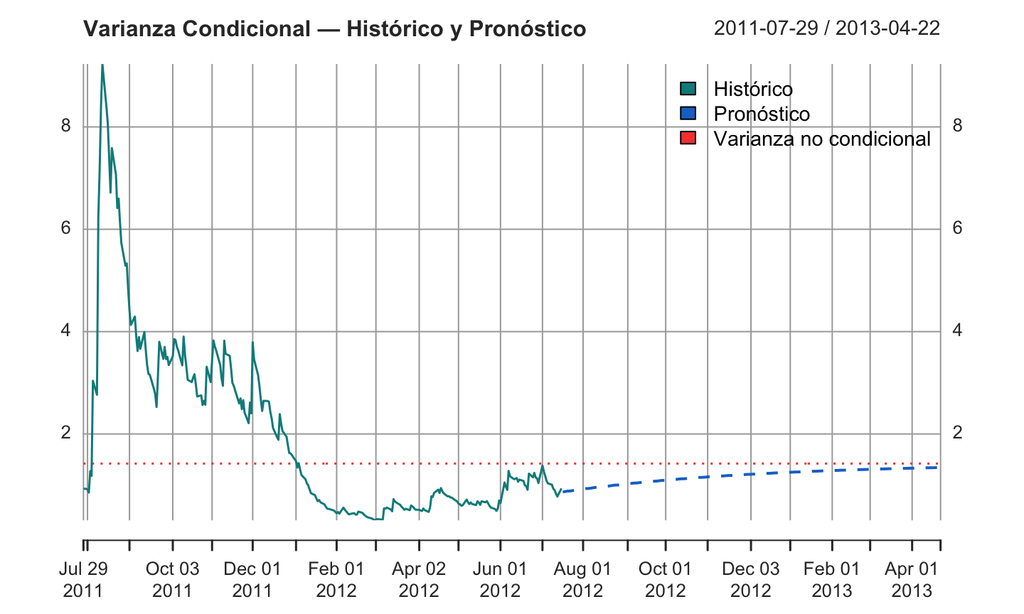

## Ejemplo GARCH: Brent (1/3)

Considera el rendimiento del precio spot semanal del Brent (15/may/1987–1/nov/2013).

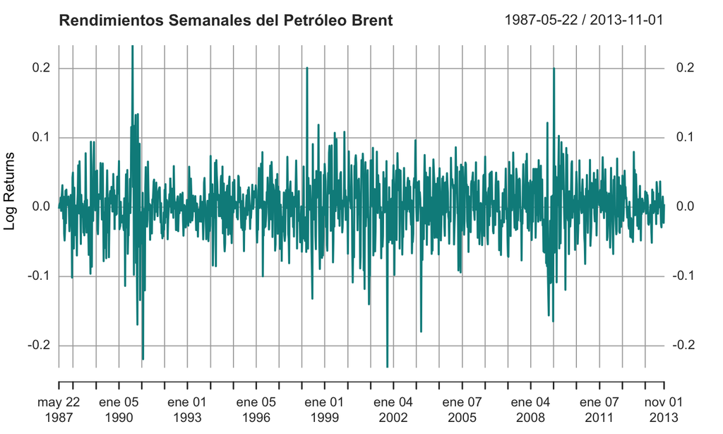

## Ejemplo GARCH: Brent (2/3)

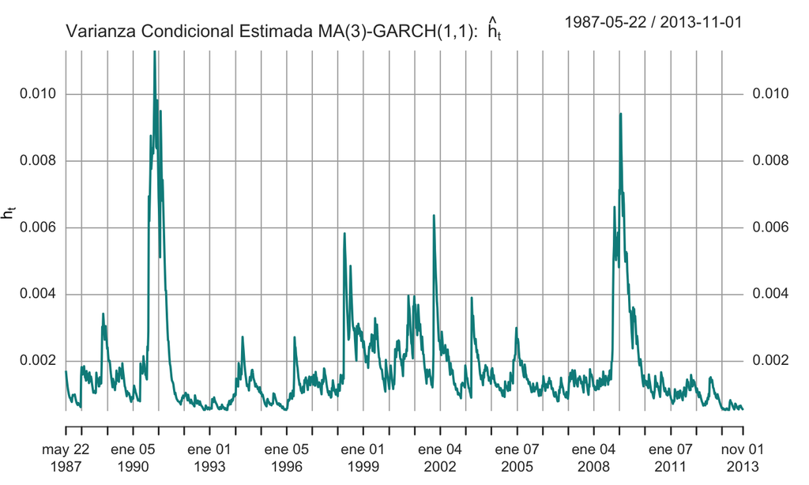

## Ejemplo GARCH: Brent (3/3)

Finalmente, un pronóstico de \(h_t\) para \(s=200\) periodos hacia adelante resulta en:

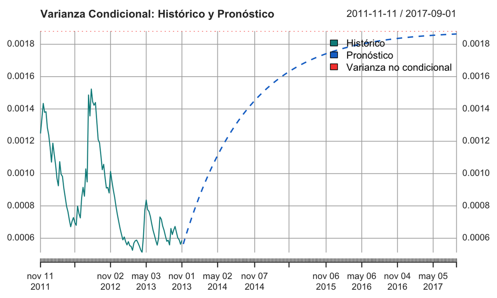